# Project 4: Credit Card Spending Analysis- Clustering

# Data Introduction

## Dataset Overview

We use the Kaggle Credit Card Dataset (CC GENERAL.csv) containing 8,950 anonymized customer records over 6 months.

Link: https://www.kaggle.com/datasets/arjunbhasin2013/ccdata

Key features:

- BALANCE – Current credit-card balance
- PURCHASES – Total purchase amount
- ONEOFF_PURCHASES – Largest single purchase
- INSTALLMENTS_PURCHASES – Amount spent on installments
- CASH_ADVANCE – Cash withdrawn
- PURCHASES_FREQUENCY – How often purchases are made (0–1)
- PAYMENTS – Total payments made
- CREDIT_LIMIT – Cwustomer credit limit
- MINIMUM_PAYMENTS – Minimum payments made
- PRC_FULL_PAYMENT – Percent of full balance paid
- TENURE – Months as customer (mostly 12)

```python
import pandas as pd
import numpy as np
import matplotlib.pyplot as plt
import seaborn as sns
from sklearn.preprocessing import StandardScaler
from sklearn.cluster import KMeans
from sklearn.metrics import silhouette_score
from sklearn.impute import SimpleImputer
from scipy.cluster.hierarchy import dendrogram, linkage, fcluster
from IPython.display import display # For notebook-friendly outputs

sns.set(style="whitegrid")
plt.rcParams["figure.figsize"] = (10,6)

# Make plots appear inline
%matplotlib inline
```

```python
df = pd.read_csv("datasets/CC.csv")

columns = [
        'BALANCE', 'PURCHASES', 'ONEOFF_PURCHASES', 'INSTALLMENTS_PURCHASES',
        'PURCHASES_FREQUENCY', 'PAYMENTS', 'CREDIT_LIMIT', 'CASH_ADVANCE', 'CUST_ID'
    ]
# Preview data
print("Data Head:")
display(df.head())
```

```
Data Head:
```

|  | CUST_ID | BALANCE | BALANCE_FREQUENCY | PURCHASES | ONEOFF_PURCHASES | INSTALLMENTS_PURCHASES | CASH_ADVANCE | PURCHASES_FREQUENCY | ONEOFF_PURCHASES_FREQUENCY | PURCHASES_INSTALLMENTS_FREQUENCY | CASH_ADVANCE_FREQUENCY | CASH_ADVANCE_TRX | PURCHASES_TRX | CREDIT_LIMIT | PAYMENTS | MINIMUM_PAYMENTS | PRC_FULL_PAYMENT | TENURE |
| --- | --- | --- | --- | --- | --- | --- | --- | --- | --- | --- | --- | --- | --- | --- | --- | --- | --- | --- |
| 0 | C10001 | 40.900749 | 0.818182 | 95.40 | 0.00 | 95.4 | 0.000000 | 0.166667 | 0.000000 | 0.083333 | 0.000000 | 0 | 2 | 1000.0 | 201.802084 | 139.509787 | 0.000000 | 12 |
| 1 | C10002 | 3202.467416 | 0.909091 | 0.00 | 0.00 | 0.0 | 6442.945483 | 0.000000 | 0.000000 | 0.000000 | 0.250000 | 4 | 0 | 7000.0 | 4103.032597 | 1072.340217 | 0.222222 | 12 |
| 2 | C10003 | 2495.148862 | 1.000000 | 773.17 | 773.17 | 0.0 | 0.000000 | 1.000000 | 1.000000 | 0.000000 | 0.000000 | 0 | 12 | 7500.0 | 622.066742 | 627.284787 | 0.000000 | 12 |
| 3 | C10004 | 1666.670542 | 0.636364 | 1499.00 | 1499.00 | 0.0 | 205.788017 | 0.083333 | 0.083333 | 0.000000 | 0.083333 | 1 | 1 | 7500.0 | 0.000000 | NaN | 0.000000 | 12 |
| 4 | C10005 | 817.714335 | 1.000000 | 16.00 | 16.00 | 0.0 | 0.000000 | 0.083333 | 0.083333 | 0.000000 | 0.000000 | 0 | 1 | 1200.0 | 678.334763 | 244.791237 | 0.000000 | 12 |

# ===================================================

# What is Clustering?

## Understanding Clustering

Clustering is an unsupervised machine learning method that groups similar observations into clusters based on patterns in the data. Unlike supervised learning, there are no target labels — the algorithm identifies structure on its own.

This project mainly uses K-Means clustering, which works by:

Choosing a number of clusters, k,

Randomly assigning k centroids,

Assigning each data point to the nearest centroid,

Recalculating centroids based on assigned points,

Repeating the process until cluster assignments stabilize.

To choose the best value of k, the project uses both the elbow method and the silhouette score, which compares how similar points are to their own cluster vs. other clusters.

The code also imports hierarchical clustering tools (linkage and dendrogram), which provide an alternative clustering method based on merging observations step-by-step, although the main results come from K-Means.

# ===================================================

# Data Understanding & Visualization

## Exploratory Insights

```
Missing values per feature:
 CUST_ID                               0
BALANCE                               0
BALANCE_FREQUENCY                     0
PURCHASES                             0
ONEOFF_PURCHASES                      0
INSTALLMENTS_PURCHASES                0
CASH_ADVANCE                          0
PURCHASES_FREQUENCY                   0
ONEOFF_PURCHASES_FREQUENCY            0
PURCHASES_INSTALLMENTS_FREQUENCY      0
CASH_ADVANCE_FREQUENCY                0
CASH_ADVANCE_TRX                      0
PURCHASES_TRX                         0
CREDIT_LIMIT                          1
PAYMENTS                              0
MINIMUM_PAYMENTS                    313
PRC_FULL_PAYMENT                      0
TENURE                                0
dtype: int64
```

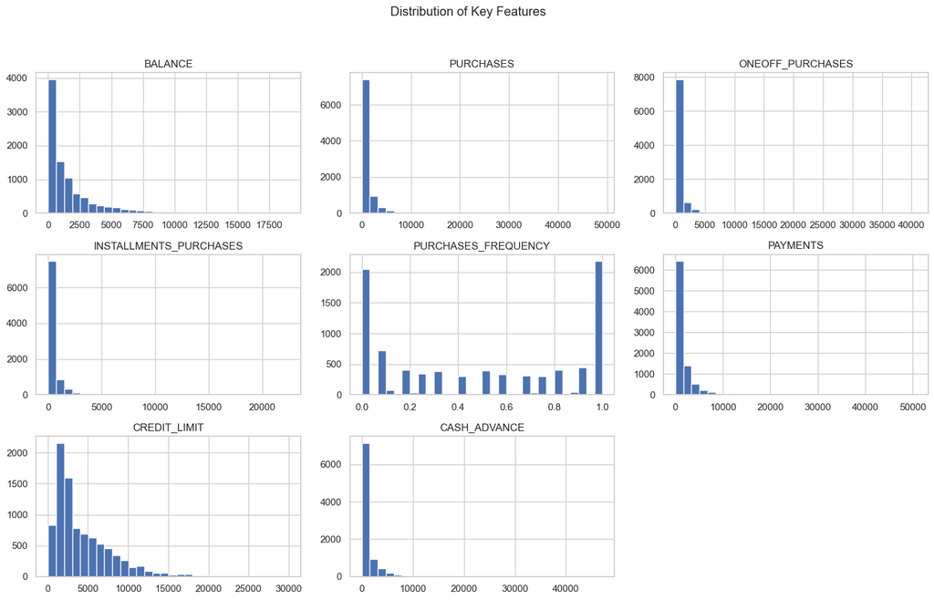

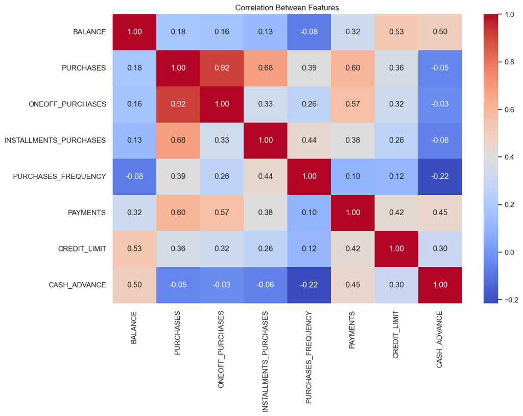

```python
# Check for missing values
print("Missing values per feature:\n", df.isnull().sum())

# Story-driven exploration: Describe what each plot tells you
numeric_features = ['BALANCE', 'PURCHASES', 'ONEOFF_PURCHASES', 'INSTALLMENTS_PURCHASES',
                    'PURCHASES_FREQUENCY', 'PAYMENTS', 'CREDIT_LIMIT', 'CASH_ADVANCE']

# Filter to features that actually exist in the dataframe
plottable_features = [col for col in numeric_features if col in df.columns]

if plottable_features:
    # Histograms
    df[plottable_features].hist(figsize=(15,10), bins=30)
    plt.suptitle("Distribution of Key Features")
    plt.tight_layout(rect=[0, 0.03, 1, 0.95]) # Adjust layout
    plt.show()

    # Correlation heatmap
    plt.figure(figsize=(12, 8))
    sns.heatmap(df[plottable_features].corr(), annot=True, cmap='coolwarm', fmt='.2f')
    plt.title("Correlation Between Features")
    plt.show()

else:
    print("Numeric features not found in DataFrame for plotting.")
```

# ===================================================

# Data Preprocessing

## Processing Steps & Rationale

- Applied **median imputation** to handle missing values in selected numeric features
  - Median chosen because it is **robust to outliers**
  - Prevents model failure due to NaNs in clustering algorithms
- Created a **copy of the dataframe** before imputing
  - Avoids Pandas `SettingWithCopyWarning` and preserves original data
- Applied **StandardScaler** to normalize the features
  - Scales each feature to mean = 0, std = 1
  - Essential for distance-based models (e.g., K-Means), where unscaled features distort results
- If no valid features exist, generates an empty array to prevent downstream errors

This preprocessing ensures the dataset is clean, numerically comparable, and ready for clustering or other ML models.

```python
# We'll use the same plottable_features list from before
if plottable_features:
    # Impute missing values with median (robust to outliers)
    imputer = SimpleImputer(strategy='median')
    # Create a copy to avoid SettingWithCopyWarning
    df_imputed = df.copy()
    df_imputed[plottable_features] = imputer.fit_transform(df[plottable_features])

    # Scale features
    scaler = StandardScaler()
    scaled_features = scaler.fit_transform(df_imputed[plottable_features])
    print("Missing values handled and features scaled successfully.")
else:
    print("No features to preprocess.")
    scaled_features = np.array([]) # Create empty array to avoid error
```

```
Missing values handled and features scaled successfully.
```